# hike_2020_11_29

saryglarroza

30 11 2020

Step by step following Pozdnyakov analysis of [Washington Trails Association](https://www.wta.org) data that were collected by [TidyX](https://github.com/thebioengineer/TidyX/tree/master/TidyTuesday_Explained/035-Rectangles) crew. It can be downloaded from [Tidy Tuesday Github](https://github.com/rfordatascience/tidytuesday/blob/master/data/2020/2020-11-24/readme.md) page or by using `tidytuesdayR` package.

## Dataset downloading

```r
library(tidyverse)
library(hrbrthemes)
```

загрузка датасета с помощью пакетов с гитхаба

```r
tuesdata <- tidytuesdayR::tt_load('2020-11-24')
hike_data <- tuesdata$hike_data
```

## Reprocessing

Ввести в консоле название “tuesdata”, запустить. Во вкладке Viewer откроется полная информация с гитхаба о датасете.

Для получения описания таблитцы в консоле вводим hike_data. Dataframe это список из векторов одинаковой длины, по-этому к ним можно обращаться как к матрице, таблице итп. Но когда в таблице содержиться колонка со списком (features ), базовый R будет работать не стабильно, выдавать ошибки, например при загрузке с помощью read.csv. Но в tidyverse можно.

Посмотрим, являются ли имена троп уникальными, чтобы их можно было использовать как ID.

```r
hike_data %>%
  count(name, sort = TRUE)
```

```
## # A tibble: 1,924 x 2
##    name               n
##    <chr>          <int>
##  1 Dry Creek          3
##  2 Rock Creek         3
##  3 Baldy Mountain     2
##  4 Beaver Lake        2
##  5 Big Tree Trail     2
##  6 Blue Lake          2
##  7 Boulder Lake       2
##  8 Canyon Lake        2
##  9 Cap Sante Park     2
## 10 Copper Creek       2
## # … with 1,914 more rows
```

```r
hike_data %>% filter(name == "Dry Creek")
```

```
## # A tibble: 3 x 8
##   name   location      length  gain  highpoint rating features description
##   <chr>  <chr>         <chr>   <chr> <chr>     <chr>  <list>   <chr>
## 1 Dry C… Olympic Peni… 6.0 mi… 800   1600.0    2.60   <chr [2… Climb through se…
## 2 Dry C… South Cascad… 8.4 mi… 350   1500.0    4.00   <chr [6… Low-lying with i…
## 3 Dry C… South Cascad… 7.4 mi… 2800  3800.0    3.00   <chr [5… One of many Dry …
```

Есть разные тропы с одинаковыми названиями. Создаем колонку с ID для троп. Другой вариант: hike_data %>% mutate(id = row_number()) %>% relocate(id) расположить id впереди всех колонок можно внутри мутейт, без релокейт. mutate(id = row_number(), .before = name)

```r
hike<- hike_data %>%
  mutate(id = row_number(), .before = everything()) %>%
  separate(col = location,
           into = c("region", "area"),
           sep = "\\s--\\s",
           fill = "right") %>%
  separate(col = length,
           into = c("length_miles", "type"),
           sep = "\\smiles,?\\s") %>%
  type_convert() %>%
  mutate(rating = na_if(rating, 0))
```

В колонке location названия идут через двойной дефис “Snoqualmie Region – Snoqualmie Pass”. Можно разбить на две колонки.

\s -регулярка, которая обозначает - любые виды пробелов.

Если не прописать fill = “right”, можно получить такое предупреждение: Expected 2 pieces. Missing pieces filled with `NA` in 38 rows [34, 73, …]. Но на самой таблице это не сказывается. Все пустые значения в обеих вариантах заполняется NA.

В колонке lenght значения идут через запятую и явно обозначают два признака - длина и форма тропы: 9.0 miles, roundtrip. Можно разделить на две колонки.

sep = “\miles,?\s”, -,?- вопросительный знак после запятой означает, что запятая может присуствовать, либо отсутствовать.

```r
hike %>%
  count(type)
```

```
## # A tibble: 3 x 2
##   type          n
##   <chr>     <int>
## 1 of trails    43
## 2 one-way     146
## 3 roundtrip  1769
```

Получили третье значение “of trails”. Проверить ошибка ли это. into = c(“length_miles”, “type”), вносим изменения.

```r
hike %>%
  filter(is.na(type))
```

```
## # A tibble: 0 x 11
## # … with 11 variables: id <int>, name <chr>, region <chr>, area <chr>,
## #   length_miles <dbl>, type <chr>, gain <dbl>, highpoint <dbl>, rating <dbl>,
## #   features <list>, description <chr>
```

Перевести колонки с цифрами в нумерик формат через type_convert (вместо конвертации каждой колонки через as.numeric или across)

```r
skimr::skim(hike)
```

Data summary

| Name | hike |
| --- | --- |
| Number of rows | 1958 |
| Number of columns | 11 |
| _______________________ |  |
| Column type frequency: |  |
| character | 5 |
| list | 1 |
| numeric | 5 |
| ________________________ |  |
| Group variables | None |

**Variable type: character**

[output not shown]

**Variable type: list**

| skim_variable | n_missing | complete_rate | n_unique | min_length | max_length |
| --- | --- | --- | --- | --- | --- |
| features | 0 | 1 | 1071 | 0 | 12 |

**Variable type: numeric**

| skim_variable | n_missing | complete_rate | mean | sd | p0 | p25 | p50 | p75 | p100 | hist |
| --- | --- | --- | --- | --- | --- | --- | --- | --- | --- | --- |
| id | 0 | 1.00 | 979.50 | 565.37 | 1.0 | 490.25 | 979.5 | 1468.75 | 1958.0 | ▇▇▇▇▇ |
| length_miles | 0 | 1.00 | 8.24 | 9.02 | 0.1 | 3.50 | 6.5 | 10.00 | 147.5 | ▇▁▁▁▁ |
| gain | 0 | 1.00 | 1715.91 | 1902.18 | 8.0 | 400.00 | 1300.0 | 2500.00 | 27996.0 | ▇▁▁▁▁ |
| highpoint | 0 | 1.00 | 3762.62 | 2312.28 | 10.0 | 1641.25 | 4089.5 | 5688.75 | 12276.0 | ▇▆▇▁▁ |
| rating | 292 | 0.85 | 3.51 | 0.75 | 1.0 | 3.00 | 3.5 | 4.00 | 5.0 | ▁▂▆▇▃ |

```r
hike %>%
  filter(rating == 0)
```

```
## # A tibble: 0 x 11
## # … with 11 variables: id <int>, name <chr>, region <chr>, area <chr>,
## #   length_miles <dbl>, type <chr>, gain <dbl>, highpoint <dbl>, rating <dbl>,
## #   features <list>, description <chr>
```

Действительно нет оценок. Следует заменить 0 на NA. ?na_if pull() вытаскивает значения выбранного вектора отдельно от датафрейма

```r
hike %>%
  pull(rating)
```

[output not shown]

[output cut: 125 more lines]

Убедились, что значения не случайные, вполне осмысленные, такая тропа существует.

```r
hike %>%
  filter(gain == max(gain))
```

```
## # A tibble: 1 x 11
##      id name  region area  length_miles type   gain highpoint rating features
##   <int> <chr> <chr>  <chr>        <dbl> <chr> <dbl>     <dbl>  <dbl> <list>
## 1   935 Paci… South… Colu…         148. one-… 27996      7800      4 <chr [1…
## # … with 1 more variable: description <chr>
```

Что делать с колонкой, в которой в каждой ячейке вектор? функция nest() позволяет создавать сжатые значения/вложенные unnest наоборот расскладывает unnest(cols = features) - разложит в длинну, те создат несколько колонок, различающихся только по значению features. При этом длина датафрейма удлиняется.

```r
hike_long<- hike %>%
  unnest(col = features)
```

```r
hike_wide<- hike %>%
  unnest(col = features) %>%
  mutate(value = TRUE) %>%
  pivot_wider(names_from = features,
              values_from = value,
              values_fill = FALSE)
```

Посмотреть среднее количесвто фичей на регион

```r
features_ratio_by_region <- hike_wide %>%
  group_by(region) %>%
  summarise(across(`Dogs allowed on leash`:Summits, mean)) %>%
  pivot_longer(cols = `Dogs allowed on leash`:Summits,
               names_to = "features",
               values_to = "ratio") %>%
  arrange(region, features)
```

## Visualization

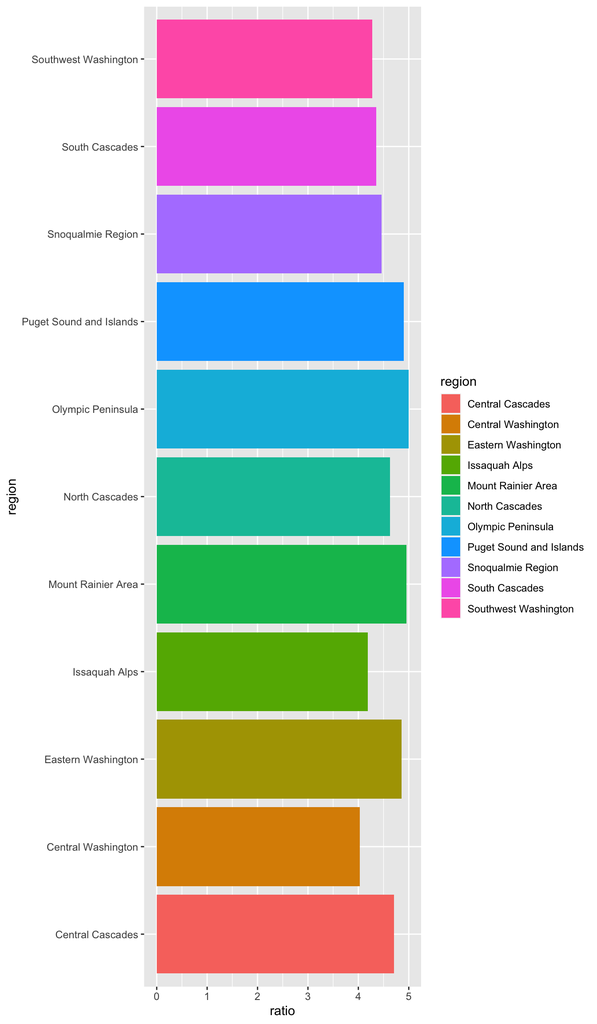

```r
features_ratio_by_region %>%
ggplot()+
  geom_bar(aes(x=region, y=ratio, fill = region), stat = "identity")+
  coord_flip()
```

limits = c(0,1) показывает на плоте значения до 100%, а не 80%, что улучшает восприятие данных

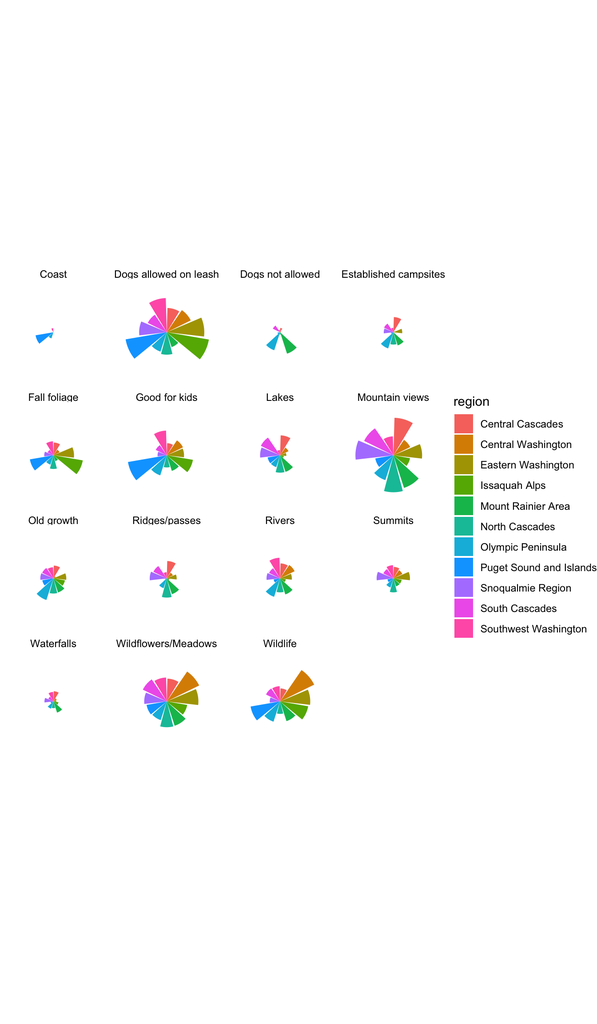

```r
features_ratio_by_region %>%
ggplot()+
  geom_col(aes(x=region, y=ratio, fill = region))+
  coord_polar()+
  facet_wrap(~features)+
  #guides(fill = FALSE)+
  theme_void()
```

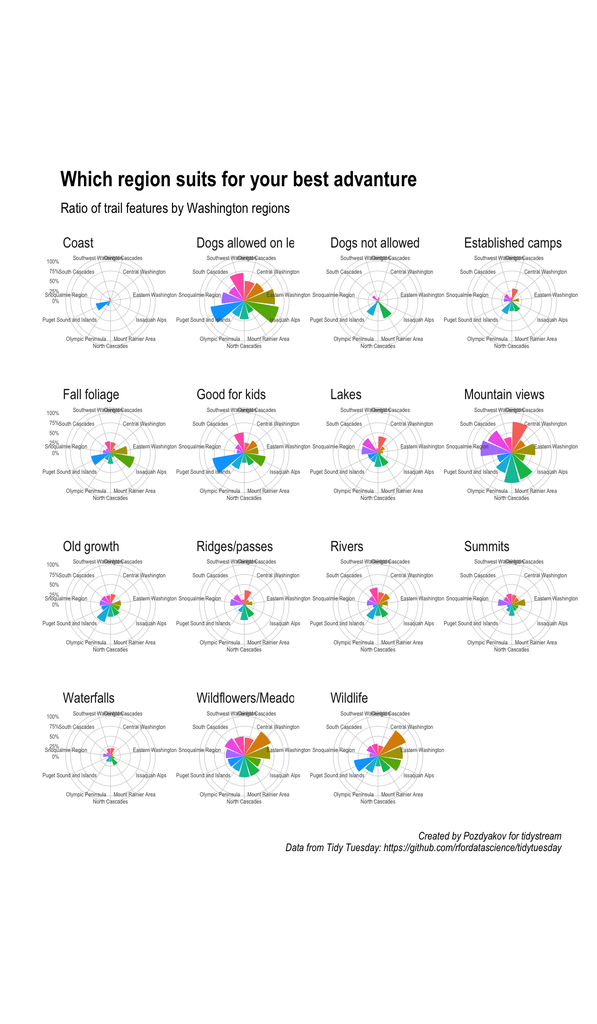

```r
features_ratio_by_region %>%
  ggplot()+
  geom_col(aes(x=region, y=ratio, fill = region))+
  coord_polar(clip = "off")+
  facet_wrap(~features)+
  scale_y_continuous(labels = scales::percent, limits = c(0,1))+
  guides(fill=FALSE)+
  labs(x = "",
       y = "",
       title = "Which region suits for your best advanture",
       subtitle = "Ratio of trail features by Washington regions",
       caption = "Created by Pozdyakov for tidystream\nData from Tidy Tuesday: https://github.com/rfordatascience/tidytuesday")+
  theme_ipsum(base_size = 5)
```